# Business Analytics: Project 1

Anatoly Kolesov

29 10 2019

# Questions:

- What are the most important factors for predicting customer churn in this bank?
- How much time does the bank have on average before a customer churns?

To answer these questions we need to explore the data, build a valid logistic regression model and perform survival analysis.

```r
data = read.csv("Churn_Modelling.csv")
library(stats)
library(ggplot2)
library(dplyr)
library(MASS)
library(descr)
library(survival)
library(SDMTools)
library(boot)
```

# Step 1: Exploring the data

First of all let’s see how many customers have churned at all:

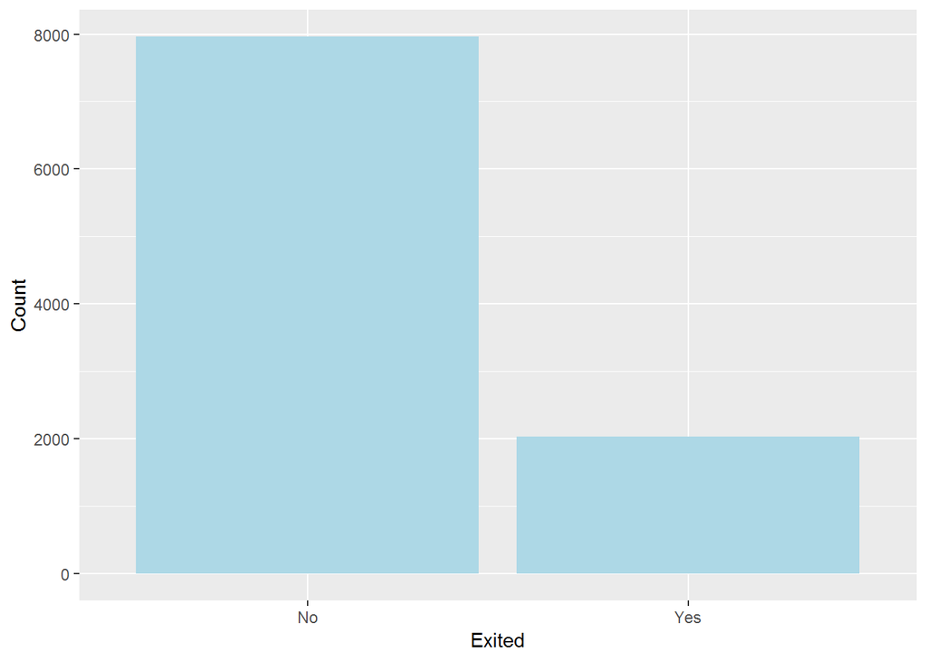

```r
dataExited <- data %>%
  mutate(Exited = Exited %>% factor(labels = c("No", "Yes")))

ggplot(dataExited, aes(x = as.factor(Exited))) +
  geom_histogram(stat = "count", fill = "lightblue") +
  labs(x = "Exited", y = "Count") +
  theme(legend.position = "none")
```

The plot shows that only 2000 out of 10000 customers have left.

Next, let’s see how much time on average churners and no-churners spend as bank’s clients:

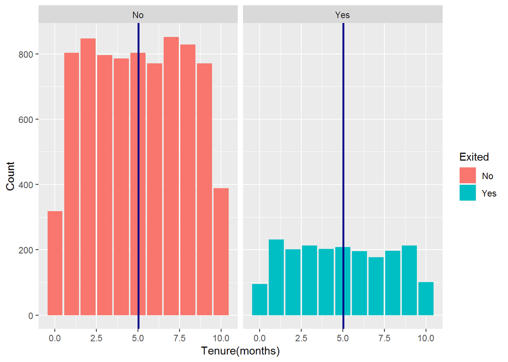

```r
ggplot(dataExited, aes(x = Tenure, fill = Exited), position = position_dodge(0.8)) +
  geom_histogram(stat = "count") +
  geom_vline(xintercept=mean(dataExited$Tenure), lwd=1, linetype=1, color="darkblue") +
  facet_grid( ~ Exited) +
  labs(y = "Count", x = "Tenure(months)")
```

The plots show that both churners and no-churners spend on average 5 months as bank clients.

```r
m1 = mean(data$Tenure)
print(paste0("Mean = ",m1))
```

```
## [1] "Mean = 5.0128"
```

Considering this number, probably the bank has opened not long ago, so all the analysis and assumptions should be made in accordance with that.

# Step 2: Predicting churn with logistic regression

To find predictors for customers churning let’s build a logistic regression model:

```r
logitModel <- glm(Exited ~ CreditScore + Geography + Gender + Age +
                   Tenure + Balance + NumOfProducts + HasCrCard + IsActiveMember + EstimatedSalary,
                family = binomial, data = data)

summary(logitModel)
```

```
##
## Call:
## glm(formula = Exited ~ CreditScore + Geography + Gender + Age +
##     Tenure + Balance + NumOfProducts + HasCrCard + IsActiveMember +
##     EstimatedSalary, family = binomial, data = data)
##
## Deviance Residuals:
##     Min       1Q   Median       3Q      Max
## -2.3097  -0.6589  -0.4560  -0.2697   2.9940
##
## Coefficients:
##                    Estimate Std. Error z value Pr(>|z|)
## (Intercept)      -3.392e+00  2.448e-01 -13.857  < 2e-16 ***
## CreditScore      -6.683e-04  2.803e-04  -2.384   0.0171 *
## GeographyGermany  7.747e-01  6.767e-02  11.448  < 2e-16 ***
## GeographySpain    3.522e-02  7.064e-02   0.499   0.6181
## GenderMale       -5.285e-01  5.449e-02  -9.699  < 2e-16 ***
## Age               7.271e-02  2.576e-03  28.230  < 2e-16 ***
## Tenure           -1.595e-02  9.355e-03  -1.705   0.0882 .
## Balance           2.637e-06  5.142e-07   5.128 2.92e-07 ***
## NumOfProducts    -1.015e-01  4.713e-02  -2.154   0.0312 *
## HasCrCard        -4.468e-02  5.934e-02  -0.753   0.4515
## IsActiveMember   -1.075e+00  5.769e-02 -18.643  < 2e-16 ***
## EstimatedSalary   4.807e-07  4.737e-07   1.015   0.3102
## ---
## Signif. codes:  0 '***' 0.001 '**' 0.01 '*' 0.05 '.' 0.1 ' ' 1
##
## (Dispersion parameter for binomial family taken to be 1)
##
##     Null deviance: 10109.8  on 9999  degrees of freedom
## Residual deviance:  8561.4  on 9988  degrees of freedom
## AIC: 8585.4
##
## Number of Fisher Scoring iterations: 5
```

```r
coefsexp <- coef(logitModel) %>% exp() %>% round(2)
coefsexp
```

```
##      (Intercept)      CreditScore GeographyGermany   GeographySpain
##             0.03             1.00             2.17             1.04
##       GenderMale              Age           Tenure          Balance
##             0.59             1.08             0.98             1.00
##    NumOfProducts        HasCrCard   IsActiveMember  EstimatedSalary
##             0.90             0.96             0.34             1.00
```

The logistic regression model suggests that gender, age, current balance, activeness as a member and geographical location in Germany are statistically significant for predicting churn.

Let’s go ahead and try to find variables that are irrelevant for predicting churn.

### Model selection

```r
logitModelNew <- stepAIC(logitModel,trace = 0)

summary(logitModelNew)
```

```
##
## Call:
## glm(formula = Exited ~ CreditScore + Geography + Gender + Age +
##     Tenure + Balance + NumOfProducts + IsActiveMember, family = binomial,
##     data = data)
##
## Deviance Residuals:
##     Min       1Q   Median       3Q      Max
## -2.3270  -0.6592  -0.4553  -0.2682   2.9826
##
## Coefficients:
##                    Estimate Std. Error z value Pr(>|z|)
## (Intercept)      -3.377e+00  2.359e-01 -14.312  < 2e-16 ***
## CreditScore      -6.682e-04  2.803e-04  -2.384   0.0171 *
## GeographyGermany  7.741e-01  6.766e-02  11.441  < 2e-16 ***
## GeographySpain    3.586e-02  7.063e-02   0.508   0.6116
## GenderMale       -5.291e-01  5.448e-02  -9.712  < 2e-16 ***
## Age               7.268e-02  2.575e-03  28.230  < 2e-16 ***
## Tenure           -1.595e-02  9.350e-03  -1.706   0.0879 .
## Balance           2.653e-06  5.140e-07   5.162 2.45e-07 ***
## NumOfProducts    -1.007e-01  4.712e-02  -2.137   0.0326 *
## IsActiveMember   -1.075e+00  5.767e-02 -18.648  < 2e-16 ***
## ---
## Signif. codes:  0 '***' 0.001 '**' 0.01 '*' 0.05 '.' 0.1 ' ' 1
##
## (Dispersion parameter for binomial family taken to be 1)
##
##     Null deviance: 10110  on 9999  degrees of freedom
## Residual deviance:  8563  on 9990  degrees of freedom
## AIC: 8583
##
## Number of Fisher Scoring iterations: 5
```

```r
coefsexp <- coef(logitModelNew) %>% exp() %>% round(2)
coefsexp
```

```
##      (Intercept)      CreditScore GeographyGermany   GeographySpain
##             0.03             1.00             2.17             1.04
##       GenderMale              Age           Tenure          Balance
##             0.59             1.08             0.98             1.00
##    NumOfProducts   IsActiveMember
##             0.90             0.34
```

The new model suggests that variables **HasCrCard** and **EstimatedSalary** can be dropped from the model.

Before drowing any conclusions let’s check the quality of the model with several methods.

### Assessing model quality

```r
LogRegR2(logitModelNew)
```

```
## Chi2                 1546.83
## Df                   9
## Sig.                 0
## Cox and Snell Index  0.1433133
## Nagelkerke Index     0.2252868
## McFadden's R2        0.1530033
```

The pseudo R2 statistics show that the explanatory power of the model is quite poor, only Nagelkerke index > 0.2 defines it as reasonable.

### Confusion matrix and in-sample accuracy

```r
data$predNew <- predict(logitModelNew, type = "response",
                     na.action = na.exclude)

confMatrixNew <- confusion.matrix(data$Exited,
                    data$predNew, threshold = 0.3)
confMatrixNew
```

```
##     obs
## pred    0    1
##    0 6808 1009
##    1 1155 1028
## attr(,"class")
## [1] "confusion.matrix"
```

```r
accuracyNew <- sum(diag(confMatrixNew)) / sum(confMatrixNew)
accuracyNew
```

```
## [1] 0.7836
```

The confusion matrix shows that the accuracy of the model at a threshold of 0.3 is 78%.

### Cross-validation

To check for overfitting let’s do cross-validation and look at the cross-validated accuracy of the model.

```r
costAcc <- function(r, pi = 0) {
  cm <- confusion.matrix(r, pi, threshold = 0.3)
  acc <- sum(diag(cm)) / sum(cm)
  return(acc)
}

set.seed(534381)
cv.glm(data, logitModelNew, cost = costAcc, K = 6)$delta[1]
```

```
## [1] 0.7817
```

The cross-validated accuracy of the model is also 78%.

Now we can pick some factors for predictions.

```r
summary(logitModelNew)
```

```
##
## Call:
## glm(formula = Exited ~ CreditScore + Geography + Gender + Age +
##     Tenure + Balance + NumOfProducts + IsActiveMember, family = binomial,
##     data = data)
##
## Deviance Residuals:
##     Min       1Q   Median       3Q      Max
## -2.3270  -0.6592  -0.4553  -0.2682   2.9826
##
## Coefficients:
##                    Estimate Std. Error z value Pr(>|z|)
## (Intercept)      -3.377e+00  2.359e-01 -14.312  < 2e-16 ***
## CreditScore      -6.682e-04  2.803e-04  -2.384   0.0171 *
## GeographyGermany  7.741e-01  6.766e-02  11.441  < 2e-16 ***
## GeographySpain    3.586e-02  7.063e-02   0.508   0.6116
## GenderMale       -5.291e-01  5.448e-02  -9.712  < 2e-16 ***
## Age               7.268e-02  2.575e-03  28.230  < 2e-16 ***
## Tenure           -1.595e-02  9.350e-03  -1.706   0.0879 .
## Balance           2.653e-06  5.140e-07   5.162 2.45e-07 ***
## NumOfProducts    -1.007e-01  4.712e-02  -2.137   0.0326 *
## IsActiveMember   -1.075e+00  5.767e-02 -18.648  < 2e-16 ***
## ---
## Signif. codes:  0 '***' 0.001 '**' 0.01 '*' 0.05 '.' 0.1 ' ' 1
##
## (Dispersion parameter for binomial family taken to be 1)
##
##     Null deviance: 10110  on 9999  degrees of freedom
## Residual deviance:  8563  on 9990  degrees of freedom
## AIC: 8583
##
## Number of Fisher Scoring iterations: 5
```

```r
coefsexp <- coef(logitModelNew) %>% exp() %>% round(2)
coefsexp
```

```
##      (Intercept)      CreditScore GeographyGermany   GeographySpain
##             0.03             1.00             2.17             1.04
##       GenderMale              Age           Tenure          Balance
##             0.59             1.08             0.98             1.00
##    NumOfProducts   IsActiveMember
##             0.90             0.34
```

Based on the model, several factors for predicting churn can be picked:

- **Geography**: Customers whose place of residence is Germany are more than twice (117%) likely to churn compared to customers from France, while customers from Spain are only 4% more likely to churn compared to French ones. This discovery leads to a conclusion that for some reasons customers from Germany are most likely to churn and probably some further investigation of German market should be done.
- **Number of Products**: With every additional product (bank cards/accounts/affiliated products) a customer has their probability to churn decreases by 10%. This is intuitively understandable, the more customer is engaged with the bank, the more likely he/she is not to churn.
- **Being active member**: Customers who are active members are 66% less likely to churn compared to those who are considered not active members. Since it is not very clear how this variable is measured more information is needed to draw conlusions and develop policies from this predictor.

# Step 3: Predicting time to churn

In order to predict time to churn we perform survival analysis.

```r
surv <- Surv(data$Tenure, data$Exited)

dataSurv <- cbind(data$Tenure, data$Exited, Surv = surv)

fitKM <- survfit(Surv(data$Tenure, data$Exited) ~ 1,
                 type = "kaplan-meier")
fitKM$surv
```

```
##  [1] 0.9905000 0.9665305 0.9438138 0.9170238 0.8883624 0.8546414 0.8173673
##  [8] 0.7763483 0.7151476 0.6118054 0.4856986
```

```r
print(fitKM)
```

```
## Call: survfit(formula = Surv(data$Tenure, data$Exited) ~ 1, type = "kaplan-meier")
##
##       n  events  median 0.95LCL 0.95UCL
##   10000    2037      10      10      NA
```

The output shows that the data contains n = 10000 observations (clients), of which 2037 have already churned. The median is 10 months, which means 50% of customers stay as clients for 10 months.

To make it more explicit, here’s the plot of survival function of bank clients derived from the given data. The survival function shows the probability of a customer not churning at each point in time.

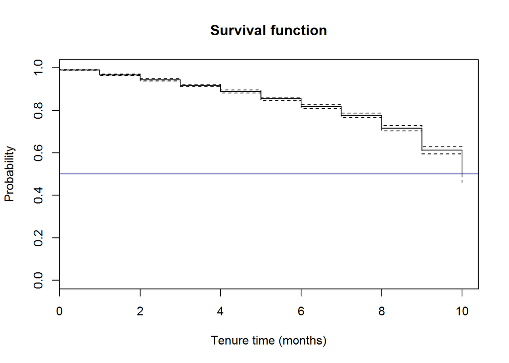

```r
plot(fitKM,
     main = "Survival function",
     xlab = "Tenure time (months)",
     ylab = "Probability")

abline(h = 0.5, col = 'darkblue', lwd = 1)
```

From this picture we can see that within first 10 months our clients will not churn with probability > 0.5, so on average bank has ~ 10 months before the probability of a customer churning becomes higher than 0.5.

# Conclusions